# Solution_Fullcode_SL_additional_Project_1

## Problem Statement

### Business Context

Airbnb is an online platform that allows people to rent short-term accommodation. This ranges from regular people with a spare bedroom to property management firms who lease multiple rentals. On the one side, Airbnb enables owners to list their space and earn rental money. On the other side, it provides travelers easy access to renting private homes.

Airbnb receives commissions from two sources upon every booking, namely from the hosts and guests. For every booking, Airbnb charges the guest 6-12% of the booking fee. Moreover, Airbnb charges the host 3% for every successful transaction.

As a senior data scientist at Airbnb, you have to come up with a pricing model that can effectively predict the Rent for accommodation and can help hosts, travelers, and also the business in devising profitable strategies.

### Objective

To explore and visualize the data, build a linear regression model to predict the prices of Airbnb rental rooms, and generate a set of insights and recommendations that will help the business.

### Data Description

The data contains information about the different types of rental rooms offered by Airbnb over a fixed period of time. The detailed data dictionary is given below.

**Data Dictionary**

- id: Property ID
- room_type: Type of Room in the property
- accommodates: How many adults can this property accommodate
- bathrooms: Number of bathrooms on the property
- cancellation_policy: Cancellation policy of the property
- cleaning_fee: This denotes whether the property cleaning fee is included in the rent or not
- instant_bookable: It indicates whether an instant booking facility is available or not
- review_scores_rating: Review rating score of the property
- bedrooms: Number of bedrooms in the property
- beds: Total number of beds in the property
- log_price: Log of the rental price of the property for a fixed period. [If the price is 12000 dollars, then log_price represents log(12000)]

## Importing necessary libraries

```python
# this will help in making the Python code more structured automatically (good coding practice)
# %load_ext nb_black

# Libraries to help with reading and manipulating data
import numpy as np
import pandas as pd

# Libraries to help with data visualization
import matplotlib.pyplot as plt
%matplotlib inline

import seaborn as sns

sns.set()

# Removes the limit for the number of displayed columns
pd.set_option("display.max_columns", None)

# Sets the limit for the number of displayed rows
pd.set_option("display.max_rows", 200)

# to split the data into train and test
from sklearn.model_selection import train_test_split

# to build linear regression_model
from sklearn.linear_model import LinearRegression

# to check model performance
from sklearn.metrics import mean_absolute_error, mean_squared_error, r2_score

# to suppress warnings
import warnings

warnings.filterwarnings("ignore")
```

## Loading the dataset

```python
# Connecting Google drive
from google.colab import drive
drive.mount('/content/drive')
```

```python
# Loading the data from the source csv located in Google drive into a dataframe
data = pd.read_csv('/content/drive/MyDrive/PGP-AIML/Machine Learning/Project-2/AirBNB-1.csv')
```

```python
# Keeping a copy of the original data.
df = data.copy()
```

## Data Overview

### Displaying the first few rows of the dataset

```python
df.head()
```

|  | id | room_type | accommodates | bathrooms | cancellation_policy | cleaning_fee | instant_bookable | review_scores_rating | bedrooms | beds | log_price |
| --- | --- | --- | --- | --- | --- | --- | --- | --- | --- | --- | --- |
| 0 | 6901257 | Entire home/apt | 3.0 | 1.0 | strict | True | f | 100.0 | 1.0 | 1.0 | 5.010635 |
| 1 | 6304928 | Entire home/apt | 7.0 | 1.0 | strict | True | t | 93.0 | 3.0 | 3.0 | 5.129899 |
| 2 | 7919400 | Entire home/apt | 5.0 | 1.0 | moderate | True | t | 92.0 | 1.0 | 3.0 | 4.976734 |
| 3 | 13418779 | Entire home/apt | 4.0 | 1.0 | flexible | True | f | NaN | 2.0 | 2.0 | 6.620073 |
| 4 | 3808709 | Entire home/apt | 2.0 | 1.0 | moderate | True | t | 40.0 | 0.0 | 1.0 | 4.744932 |

### Checking the shape of the dataset

```python
# checking shape of the data
print(f"There are {df.shape[0]} rows and {df.shape[1]} columns.")
```

```
There are 74111 rows and 11 columns.
```

### Checking 10 random rows of the dataset

```python
# let's view a sample of the data
df.sample(n=10, random_state=1)
```

|  | id | room_type | accommodates | bathrooms | cancellation_policy | cleaning_fee | instant_bookable | review_scores_rating | bedrooms | beds | log_price |
| --- | --- | --- | --- | --- | --- | --- | --- | --- | --- | --- | --- |
| 56850 | 13586614 | Entire home/apt | 5.0 | 2.0 | strict | False | f | 100.0 | 2.0 | 3.0 | 7.408531 |
| 68140 | 18222981 | Private room | 3.0 | 1.0 | strict | True | f | 95.0 | 1.0 | 2.0 | 4.605170 |
| 23189 | 13915528 | Entire home/apt | 2.0 | 1.0 | strict | True | f | 95.0 | 1.0 | 2.0 | 4.094345 |
| 47255 | 7122067 | Private room | 1.0 | 1.0 | flexible | False | f | 100.0 | 1.0 | 1.0 | 4.317488 |
| 45933 | 12384924 | Entire home/apt | 5.0 | 2.0 | strict | True | f | 95.0 | 2.0 | 3.0 | 5.433722 |
| 66955 | 3999628 | Private room | 2.0 | 1.0 | moderate | True | f | 98.0 | 1.0 | 1.0 | 5.010635 |
| 18553 | 4948442 | Entire home/apt | 1.0 | 1.0 | strict | False | f | NaN | 0.0 | 1.0 | 5.010635 |
| 26117 | 666837 | Shared room | 16.0 | 2.0 | flexible | False | f | 76.0 | 1.0 | 1.0 | 2.708050 |
| 65737 | 15929932 | Entire home/apt | 10.0 | 1.0 | strict | False | f | 93.0 | 2.0 | 2.0 | 4.976734 |
| 8915 | 21173263 | Entire home/apt | 3.0 | 1.0 | strict | True | f | 95.0 | 0.0 | 2.0 | 4.700480 |

```python
# Lets drop the id column as that doesn't add any value to the EDA
df.drop('id', axis=1, inplace=True)
```

### Checking the data types of the columns for the dataset

```python
# checking column datatypes and number of non-null values
df.info()
```

```
<class 'pandas.core.frame.DataFrame'>
RangeIndex: 74111 entries, 0 to 74110
Data columns (total 10 columns):
 #   Column                Non-Null Count  Dtype
---  ------                --------------  -----
 0   room_type             74106 non-null  object
 1   accommodates          74108 non-null  float64
 2   bathrooms             73908 non-null  float64
 3   cancellation_policy   74103 non-null  object
 4   cleaning_fee          74107 non-null  object
 5   instant_bookable      74111 non-null  object
 6   review_scores_rating  57389 non-null  float64
 7   bedrooms              74019 non-null  float64
 8   beds                  73980 non-null  float64
 9   log_price             74111 non-null  float64
dtypes: float64(6), object(4)
memory usage: 5.7+ MB
```

**Observations**

- 4 columns are of the *object* type columns and 6 columns are of *numerical* type columns. We will eventually need to convert the object type columns into numerical as applicable.

### Checking for duplicate values

```python
# checking for duplicate values
df.duplicated().sum()
```

```
19994
```

**Observations**

- There are 19994 duplicate rows.
- Let's take a closer look at it.

```python
df[df.duplicated(keep=False) == True].sort_values(by='accommodates').sort_values(by='log_price').head(10)
```

|  | room_type | accommodates | bathrooms | cancellation_policy | cleaning_fee | instant_bookable | review_scores_rating | bedrooms | beds | log_price |
| --- | --- | --- | --- | --- | --- | --- | --- | --- | --- | --- |
| 4466 | Private room | 1.0 | 1.0 | flexible | False | f | NaN | 1.0 | 1.0 | 2.302585 |
| 53916 | Private room | 1.0 | 1.0 | flexible | False | f | NaN | 1.0 | 1.0 | 2.302585 |
| 53792 | Private room | 1.0 | 1.0 | flexible | False | f | NaN | 1.0 | 1.0 | 2.302585 |
| 56535 | Shared room | 4.0 | 4.0 | strict | False | t | 89.0 | 1.0 | 10.0 | 2.708050 |
| 5215 | Shared room | 4.0 | 4.0 | strict | False | t | 87.0 | 1.0 | 10.0 | 2.708050 |
| 64295 | Shared room | 3.0 | 3.0 | strict | False | t | 88.0 | 1.0 | 8.0 | 2.708050 |
| 70024 | Shared room | 4.0 | 4.0 | strict | False | t | 89.0 | 1.0 | 10.0 | 2.708050 |
| 69637 | Shared room | 3.0 | 3.0 | strict | False | t | 88.0 | 1.0 | 8.0 | 2.708050 |
| 68535 | Shared room | 1.0 | 1.0 | flexible | False | f | 83.0 | 1.0 | 1.0 | 2.708050 |
| 60058 | Shared room | 4.0 | 4.0 | strict | False | t | 89.0 | 1.0 | 10.0 | 2.708050 |

**Observations**

- Looking at the data, there is a high chance that we could be duplicate rows.
- So, we will drop the rows which are duplicate

```python
df.drop_duplicates(inplace=True)
df.shape
```

```
(54117, 10)
```

```python
# checking for duplicate values again
df.duplicated().sum()
```

```
0
```

**Observations**

- After dropping the duplicates, we now have 54117 rows and no duplicate rows

### Statistical summary of the dataset

```python
df.describe()
```

|  | accommodates | bathrooms | review_scores_rating | bedrooms | beds | log_price |
| --- | --- | --- | --- | --- | --- | --- |
| count | 54114.000000 | 53922.000000 | 43902.000000 | 54025.000000 | 53992.000000 | 54117.000000 |
| mean | 3.525982 | 1.304829 | 93.202041 | 1.363258 | 1.917710 | 4.865796 |
| std | 2.343854 | 0.651167 | 8.382243 | 0.951493 | 1.384241 | 0.755754 |
| min | 1.000000 | 0.000000 | 20.000000 | 0.000000 | 0.000000 | 0.000000 |
| 25% | 2.000000 | 1.000000 | 90.000000 | 1.000000 | 1.000000 | 4.369448 |
| 50% | 3.000000 | 1.000000 | 95.000000 | 1.000000 | 1.000000 | 4.828314 |
| 75% | 4.000000 | 1.500000 | 99.000000 | 2.000000 | 2.000000 | 5.298317 |
| max | 16.000000 | 8.000000 | 100.000000 | 10.000000 | 18.000000 | 7.600402 |

**Let's check the unique values for categorical variables.**

```python
# list of all categorical variables
cat_col = df.select_dtypes(include="object").columns.tolist()

# printing the number of occurrences of each unique value in each categorical column
for column in cat_col:
    print('Number of unique values in', column ,'are:', df[column].nunique())
    print("-" * 60)
```

```
Number of unique values in room_type are: 3
------------------------------------------------------------
Number of unique values in cancellation_policy are: 3
------------------------------------------------------------
Number of unique values in cleaning_fee are: 2
------------------------------------------------------------
Number of unique values in instant_bookable are: 2
------------------------------------------------------------
```

**Let's convert the values of '*instant_bookable*' from '*f*' and '*t*' to boolean.**

```python
df.instant_bookable.replace(["f", "t"], [False, True], inplace=True)
```

## Exploratory Data Analysis (EDA)

- EDA is an important part of any project involving data.
- It is important to investigate and understand the data better before building a model with it.
- A few questions have been mentioned below which will help you approach the analysis in the right manner and generate insights from the data.
- A thorough analysis of the data, in addition to the questions mentioned below, should be done.

**Questions**:

1. How are the prices (log_price) of properties distributed?
2. What is the market share of different cancellation policies?
3. How does the price (log_price) of a property vary by the number of bedrooms?
4. How does the price (log_price) of a property vary by the number of accommodates?
5. What are the attributes that have a strong correlation with the price (log_price) of the property?

**The below functions need to be defined to carry out the Exploratory Data Analysis.**

```python
# function to create labeled barplots


def labeled_barplot(data, feature, perc=False, n=None):
    """
    Barplot with percentage at the top

    data: dataframe
    feature: dataframe column
    perc: whether to display percentages instead of count (default is False)
    n: displays the top n category levels (default is None, i.e., display all levels)
    """

    total = len(data[feature])  # length of the column
    count = data[feature].nunique()
    if n is None:
        plt.figure(figsize=(count + 1, 5))
    else:
        plt.figure(figsize=(n + 1, 5))

    plt.xticks(rotation=90, fontsize=15)
    ax = sns.countplot(
        data=data,
        x=feature,
        palette="Paired",
        order=data[feature].value_counts().index[:n].sort_values(),
    )

    for p in ax.patches:
        if perc == True:
            label = "{:.1f}%".format(
                100 * p.get_height() / total
            )  # percentage of each class of the category
        else:
            label = p.get_height()  # count of each level of the category

        x = p.get_x() + p.get_width() / 2  # width of the plot
        y = p.get_height()  # height of the plot

        ax.annotate(
            label,
            (x, y),
            ha="center",
            va="center",
            size=12,
            xytext=(0, 5),
            textcoords="offset points",
        )  # annotate the percentage

    plt.show()  # show the plot
```

```python
# function to plot a boxplot and a histogram along the same scale.


def histogram_boxplot(data, feature, figsize=(12, 7), kde=False, bins=None):
    """
    Boxplot and histogram combined

    data: dataframe
    feature: dataframe column
    figsize: size of figure (default (12,7))
    kde: whether to the show density curve (default False)
    bins: number of bins for histogram (default None)
    """
    f2, (ax_box2, ax_hist2) = plt.subplots(
        nrows=2,  # Number of rows of the subplot grid= 2
        sharex=True,  # x-axis will be shared among all subplots
        gridspec_kw={"height_ratios": (0.25, 0.75)},
        figsize=figsize,
    )  # creating the 2 subplots
    sns.boxplot(
        data=data, x=feature, ax=ax_box2, showmeans=True, color="violet"
    )  # boxplot will be created and a star will indicate the mean value of the column
    sns.histplot(
        data=data, x=feature, kde=kde, ax=ax_hist2, bins=bins, palette="winter"
    ) if bins else sns.histplot(
        data=data, x=feature, kde=kde, ax=ax_hist2
    )  # For histogram
    ax_hist2.axvline(
        data[feature].mean(), color="green", linestyle="--"
    )  # Add mean to the histogram
    ax_hist2.axvline(
        data[feature].median(), color="black", linestyle="-"
    )  # Add median to the histogram
```

### Univariate Analysis

*log_price* (the target variable)

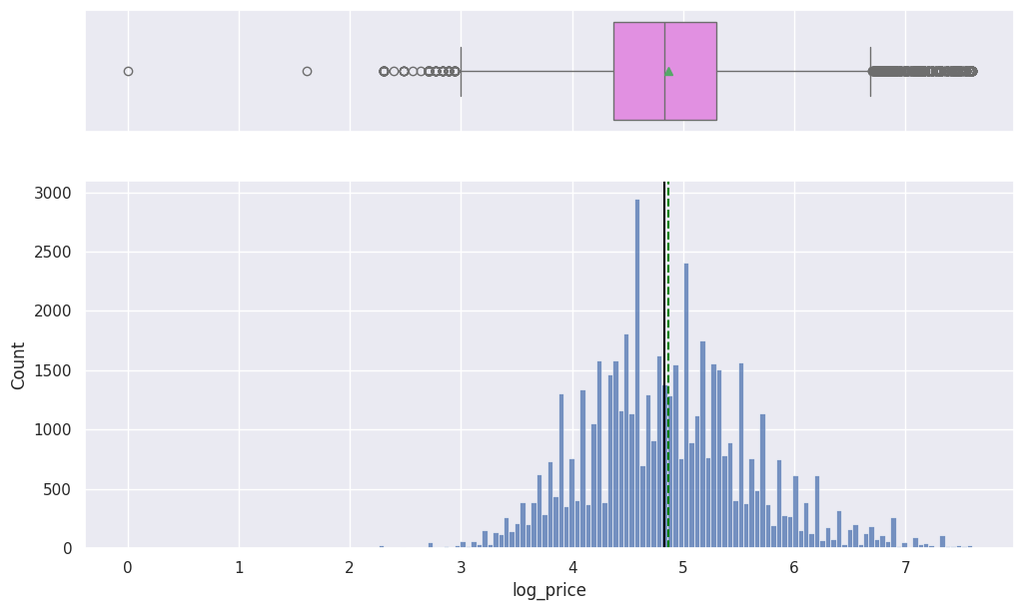

```python
histogram_boxplot(df, "log_price")
```

**Actual rental price**

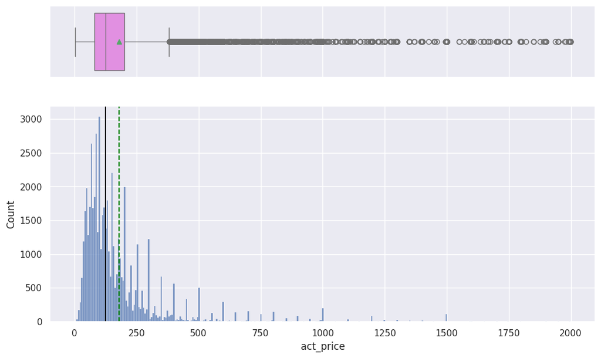

```python
df["act_price"] = np.exp(df["log_price"])
histogram_boxplot(df, 'act_price')
```

```python
# drop the act_price column
df.drop("act_price", axis=1, inplace=True)
```

*review_scores_rating*

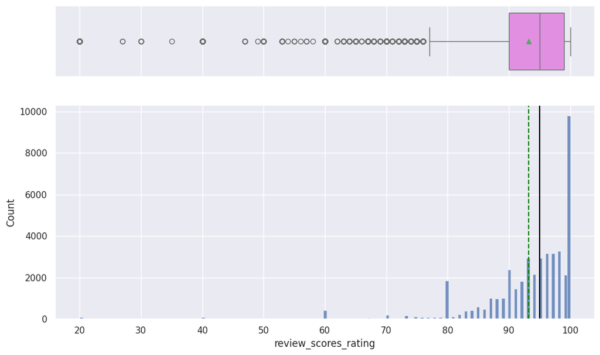

```python
histogram_boxplot(df, 'review_scores_rating')
```

*beds*

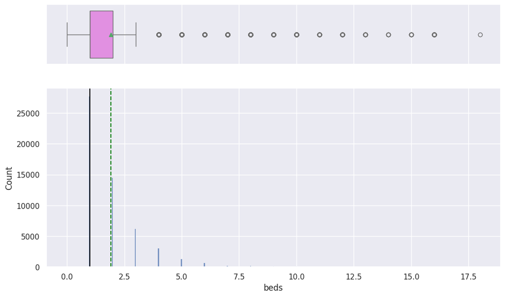

```python
histogram_boxplot(df, 'beds')
```

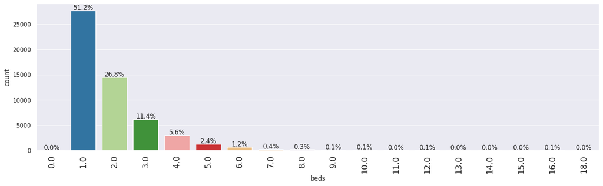

```python
labeled_barplot(df, "beds", perc=True)
```

*bedrooms*

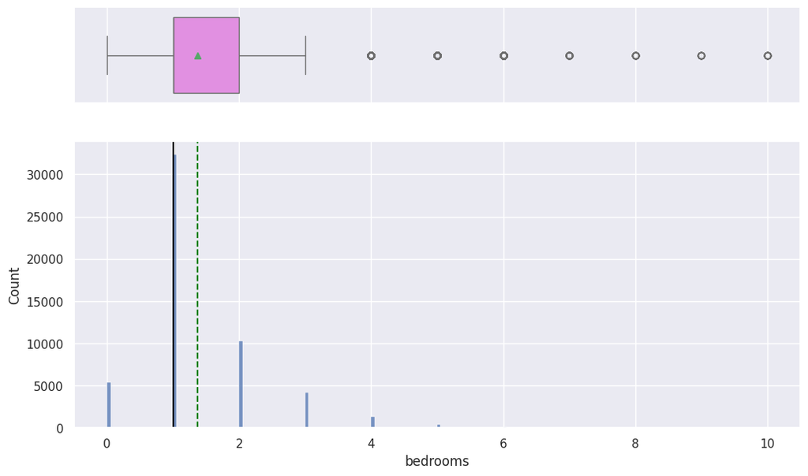

```python
histogram_boxplot(df, 'bedrooms')
```

*bathrooms*

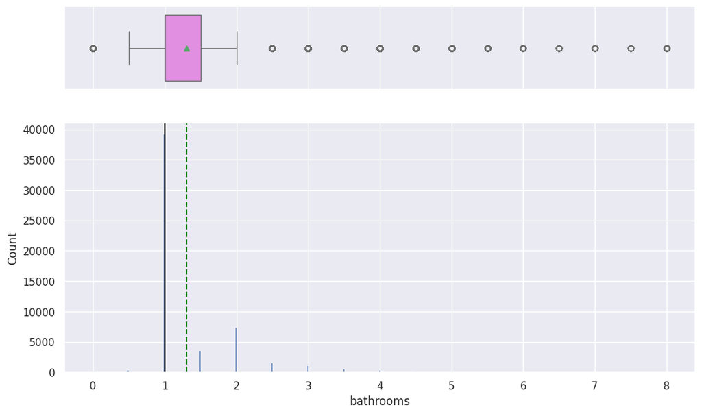

```python
histogram_boxplot(df, 'bathrooms')
```

*accommodates*

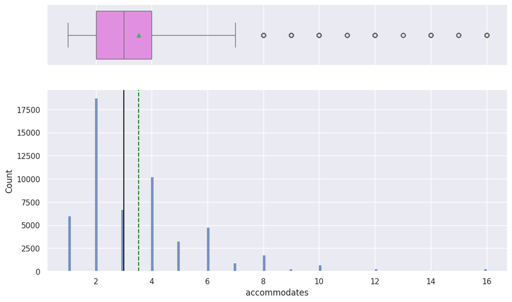

```python
histogram_boxplot(df, 'accommodates')
```

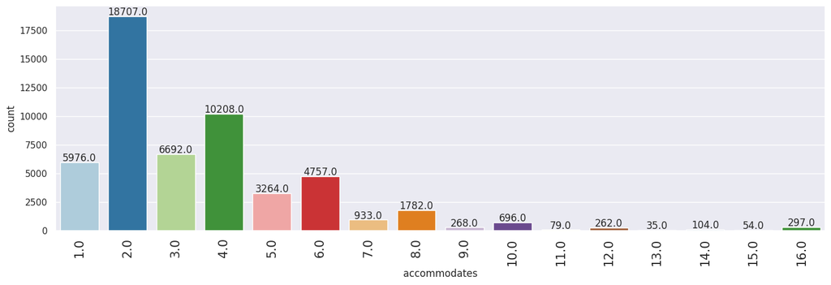

```python
labeled_barplot(df, 'accommodates')
```

*room_type*

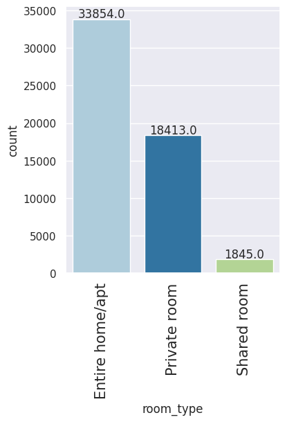

```python
labeled_barplot(df, 'room_type')
```

*cancellation_policy*

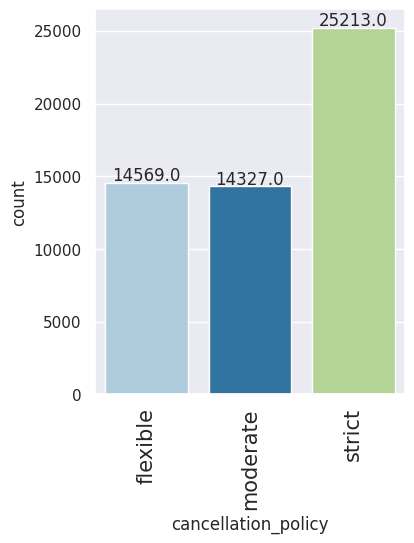

```python
labeled_barplot(df, 'cancellation_policy')
```

*cleaning_fee*

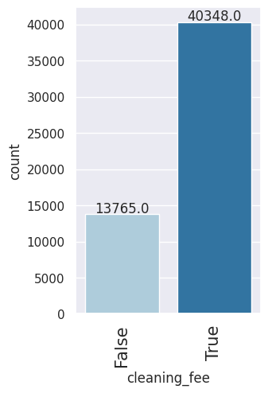

```python
labeled_barplot(df, 'cleaning_fee')
```

*instant_bookable*

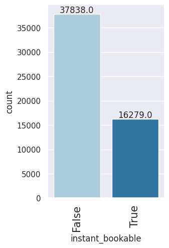

```python
labeled_barplot(df, 'instant_bookable')
```

## Bivariate Analysis

**Let's check the correlation between numerical columns.**

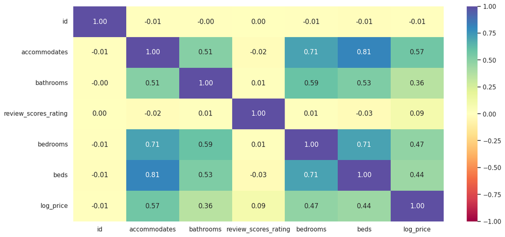

```python
plt.figure(figsize=(15, 7))
numeric_data = data.select_dtypes(include=["number"])
sns.heatmap(numeric_data.corr(), annot=True, vmin=-1, vmax=1, fmt=".2f", cmap="Spectral")
plt.show()
```

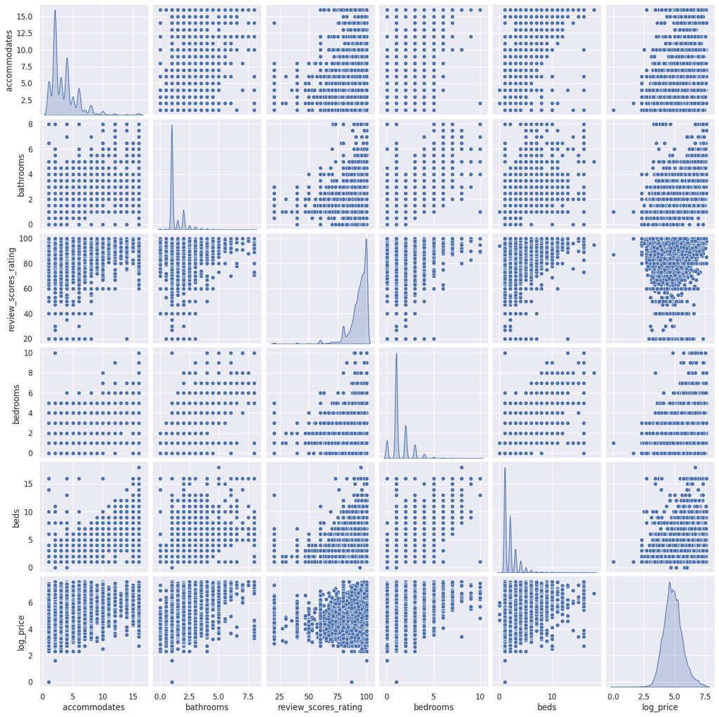

```python
numeric_columns = df.select_dtypes(include=np.number).columns.tolist()
sns.pairplot(data=df[numeric_columns], diag_kind="kde")
plt.show()
```

**Let's check the variation in *log_price* with some of the other variables.**

*accommodates* vs *log price*

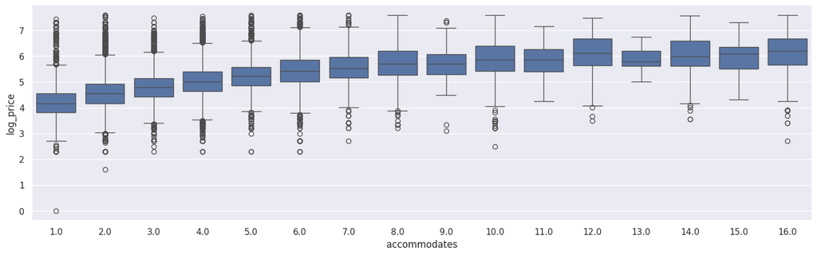

```python
plt.figure(figsize=(18, 5))
sns.boxplot(x="accommodates", y="log_price", data=df)
plt.show()
```

*bedrooms* vs *log_price*

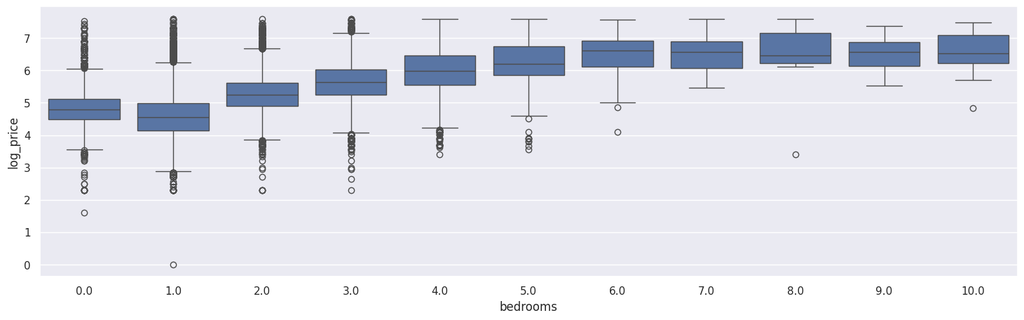

```python
plt.figure(figsize=(18, 5))
sns.boxplot(x="bedrooms", y="log_price", data=df)
plt.show()
```

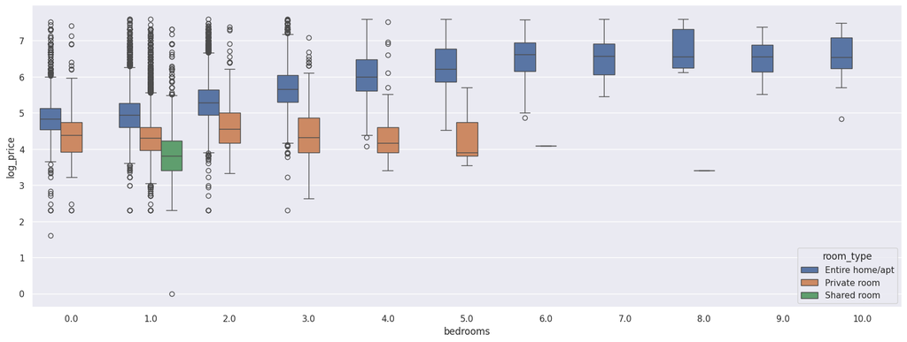

```python
plt.figure(figsize=(20, 7))
sns.boxplot(x="bedrooms", y="log_price", data=df, hue="room_type")
plt.show()
```

*Observations:*

**1) How are the prices (log_price) of properties distributed?**

- log_price seem tobe symettically distributed i.e. log_price values range between 3 and 7 mostly with 4.8 as median.
- Whereas the actual prices depict that the distribution is slightly right skewed. With few outliers. The majority of rooms have a price less than $500.

**2)What is the market share of different cancellation policies?**

- Rooms with Strict cancellation policy are more in number than rooms with flexible and moderate cancellation policies.
- Rooms with strict cancellation policy are about 25213, where as flexible and moderate are about 14569 and 14327 respectively.

**3) How does the price (log_price) of a property vary by the number of bedrooms?**

- Price of the property and bedrooms are positively coorelated. Mostly the price of the property seem to be increasing with the number of bedrooms. i.e. more number of rooms, higher the price.

**4) How does the price (log_price) of a property vary by the number of accommodates?**

- Price of the property and accommodates are positively coorelated. Mostly the price of the property seem to be increasing with the number of accommodates. i.e. rooms with higher accomodates, higher the price.

## Data Preprocessing

- Missing value treatment
- Feature engineering (if needed)
- Outlier detection and treatment (if needed)
- Preparing data for modeling
- Any other preprocessing steps (if needed)

### Missing Value Treatment

```python
df.isnull().sum()
```

```
room_type                   5
accommodates                3
bathrooms                 195
cancellation_policy         8
cleaning_fee                4
instant_bookable            0
review_scores_rating    10215
bedrooms                   92
beds                      125
log_price                   0
dtype: int64
```

```python
# list of columns for which missing values will be dropped
nonnumeric_columns = df.select_dtypes(exclude=np.number).columns
df.dropna(subset=nonnumeric_columns, inplace=True)
```

```python
df.isnull().sum()
```

```
room_type                   0
accommodates                0
bathrooms                 192
cancellation_policy         0
cleaning_fee                0
instant_bookable            0
review_scores_rating    10211
bedrooms                   92
beds                      125
log_price                   0
dtype: int64
```

```python
# list of columns for which missing values will be imputed

numeric_columns.remove("log_price")

df[numeric_columns] = df.groupby(["room_type"])[numeric_columns].transform(
    lambda x: x.fillna(x.median())
)
```

```python
df.isnull().sum()
```

```
room_type               0
accommodates            0
bathrooms               0
cancellation_policy     0
cleaning_fee            0
instant_bookable        0
review_scores_rating    0
bedrooms                0
beds                    0
log_price               0
dtype: int64
```

```python
df.describe(include="all").T
```

|  | count | unique | top | freq | mean | std | min | 25% | 50% | 75% | max |
| --- | --- | --- | --- | --- | --- | --- | --- | --- | --- | --- | --- |
| room_type | 54104 | 3 | Entire home/apt | 33848 | NaN | NaN | NaN | NaN | NaN | NaN | NaN |
| accommodates | 54104.0 | NaN | NaN | NaN | 3.52619 | 2.343964 | 1.0 | 2.0 | 3.0 | 4.0 | 16.0 |
| bathrooms | 54104.0 | NaN | NaN | NaN | 1.303776 | 0.650292 | 0.0 | 1.0 | 1.0 | 1.5 | 8.0 |
| cancellation_policy | 54104 | 3 | strict | 25211 | NaN | NaN | NaN | NaN | NaN | NaN | NaN |
| cleaning_fee | 54104 | 2 | True | 40342 | NaN | NaN | NaN | NaN | NaN | NaN | NaN |
| instant_bookable | 54104 | 2 | False | 37828 | NaN | NaN | NaN | NaN | NaN | NaN | NaN |
| review_scores_rating | 54104.0 | NaN | NaN | NaN | 93.648917 | 7.611323 | 20.0 | 92.0 | 96.0 | 98.0 | 100.0 |
| bedrooms | 54104.0 | NaN | NaN | NaN | 1.362746 | 0.950863 | 0.0 | 1.0 | 1.0 | 2.0 | 10.0 |
| beds | 54104.0 | NaN | NaN | NaN | 1.916254 | 1.383276 | 0.0 | 1.0 | 1.0 | 2.0 | 18.0 |
| log_price | 54104.0 | NaN | NaN | NaN | 4.865802 | 0.75579 | 0.0 | 4.369448 | 4.828314 | 5.298317 | 7.600402 |

```python
# adding small positive value to log_price
eps = 1e-06
df["log_price"] = df["log_price"] + eps

df["log_price"].describe()
```

```
count    54104.000000
mean         4.865803
std          0.755790
min          0.000001
25%          4.369449
50%          4.828315
75%          5.298318
max          7.600403
Name: log_price, dtype: float64
```

```python
bool_cols = ["cleaning_fee", "instant_bookable"]

df[bool_cols] = df[bool_cols].astype(int)
df.head()
```

|  | room_type | accommodates | bathrooms | cancellation_policy | cleaning_fee | instant_bookable | review_scores_rating | bedrooms | beds | log_price |
| --- | --- | --- | --- | --- | --- | --- | --- | --- | --- | --- |
| 0 | Entire home/apt | 3.0 | 1.0 | strict | 1 | 0 | 100.0 | 1.0 | 1.0 | 5.010636 |
| 1 | Entire home/apt | 7.0 | 1.0 | strict | 1 | 1 | 93.0 | 3.0 | 3.0 | 5.129900 |
| 2 | Entire home/apt | 5.0 | 1.0 | moderate | 1 | 1 | 92.0 | 1.0 | 3.0 | 4.976735 |
| 3 | Entire home/apt | 4.0 | 1.0 | flexible | 1 | 0 | 96.0 | 2.0 | 2.0 | 6.620074 |
| 4 | Entire home/apt | 2.0 | 1.0 | moderate | 1 | 1 | 40.0 | 0.0 | 1.0 | 4.744933 |

```python
df.info()
```

```
<class 'pandas.core.frame.DataFrame'>
Index: 54104 entries, 0 to 74110
Data columns (total 10 columns):
 #   Column                Non-Null Count  Dtype
---  ------                --------------  -----
 0   room_type             54104 non-null  object
 1   accommodates          54104 non-null  float64
 2   bathrooms             54104 non-null  float64
 3   cancellation_policy   54104 non-null  object
 4   cleaning_fee          54104 non-null  int64
 5   instant_bookable      54104 non-null  int64
 6   review_scores_rating  54104 non-null  float64
 7   bedrooms              54104 non-null  float64
 8   beds                  54104 non-null  float64
 9   log_price             54104 non-null  float64
dtypes: float64(6), int64(2), object(2)
memory usage: 4.5+ MB
```

### Outlier Detection

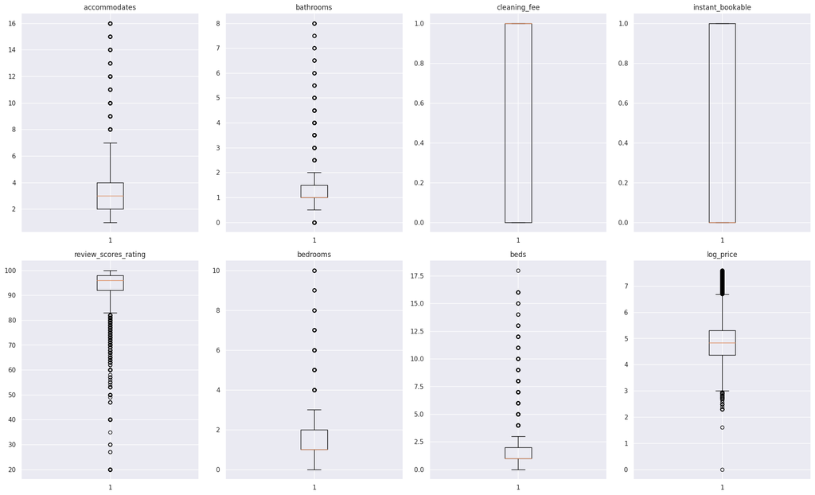

```python
# outlier detection using boxplot
numeric_columns = df.select_dtypes(include=np.number)
plt.figure(figsize=(20, 30))

for i, variable in enumerate(numeric_columns):
    plt.subplot(5, 4, i + 1)
    plt.boxplot(df[variable], whis=1.5)
    plt.tight_layout()
    plt.title(variable)

plt.show()
```

### Outlier Treatment

- Let's treat all the outliers by flooring and capping.

```python
def treat_outliers(df, col):
    """
    treats outliers in a varaible
    col: str, name of the numerical varaible
    df: data frame
    col: name of the column
    """
    Q1 = df[col].quantile(0.25)  # 25th quantile
    Q3 = df[col].quantile(0.75)  # 75th quantile
    IQR = Q3 - Q1
    Lower_Whisker = Q1 - 1.5 * IQR
    Upper_Whisker = Q3 + 1.5 * IQR
    df[col] = np.clip(
        df[col], Lower_Whisker, Upper_Whisker
    )  # all the values samller than Lower_Whisker will be assigned value of Lower_whisker
    # and all the values above upper_whishker will be assigned value of upper_Whisker
    return df


def treat_outliers_all(df, col_list):
    """
    treat outlier in all numerical varaibles
    col_list: list of numerical varaibles
    df: data frame
    """
    for c in col_list:
        df = treat_outliers(df, c)

    return df
```

```python
# treating the outliers
numerical_col = df.select_dtypes(include=np.number).columns.tolist()
df = treat_outliers_all(df, numerical_col)
```

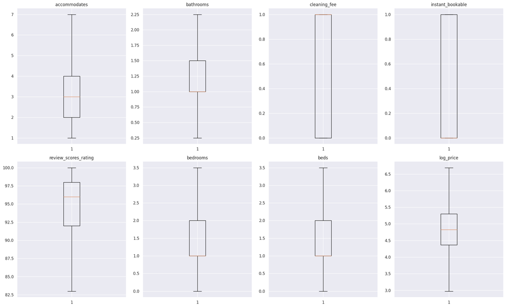

```python
# let's look at the boxplots to see if the outliers have been treated or not
plt.figure(figsize=(20, 30))

for i, variable in enumerate(numeric_columns):
    plt.subplot(5, 4, i + 1)
    plt.boxplot(df[variable], whis=1.5)
    plt.tight_layout()
    plt.title(variable)

plt.show()
```

## Model Building - Linear Regression

### Model Performance Check

**Let's check the performance of the model using different metrics.**

- We will be using metric functions defined in sklearn for RMSE, MAE, and $R^2$.
- We will define a function to calculate MAPE and adjusted $R^2$.
- We will create a function which will print out all the above metrics in one go.

```python
# function to compute adjusted R-squared
def adj_r2_score(predictors, targets, predictions):
    r2 = r2_score(targets, predictions)
    n = predictors.shape[0]
    k = predictors.shape[1]
    return 1 - ((1 - r2) * (n - 1) / (n - k - 1))


# function to compute MAPE
def mape_score(targets, predictions):
    return np.mean(np.abs(targets - predictions) / targets) * 100


# function to compute different metrics to check performance of a regression model
def model_performance_regression(model, predictors, target):
    """
    Function to compute different metrics to check regression model performance

    model: regressor
    predictors: independent variables
    target: dependent variable
    """

    # predicting using the independent variables
    pred = model.predict(predictors)

    r2 = r2_score(target, pred)  # to compute R-squared
    adjr2 = adj_r2_score(predictors, target, pred)  # to compute adjusted R-squared
    rmse = np.sqrt(mean_squared_error(target, pred))  # to compute RMSE
    mae = mean_absolute_error(target, pred)  # to compute MAE
    mape = mape_score(target, pred)  # to compute MAPE

    # creating a dataframe of metrics
    df_perf = pd.DataFrame(
        {
            "RMSE": rmse,
            "MAE": mae,
            "R-squared": r2,
            "Adj. R-squared": adjr2,
            "MAPE": mape,
        },
        index=[0],
    )

    return df_perf
```

1. We want to predict the log of rental price.
2. Before we proceed to build a model, we'll have to encode categorical features.
3. We'll split the data into train and test to be able to evaluate the model that we build on the train data.
4. We will build a Linear Regression model using the train data and then check it's performance.

### Data Preparation for modeling with log_price as Dependent variable

```python
df2=df.copy()
```

```python
# defining the dependent and independent variables
X = df.drop(["log_price"], axis=1)
y = df["log_price"]
```

```python
X.info()
```

```
<class 'pandas.core.frame.DataFrame'>
Index: 54104 entries, 0 to 74110
Data columns (total 9 columns):
 #   Column                Non-Null Count  Dtype
---  ------                --------------  -----
 0   room_type             54104 non-null  object
 1   accommodates          54104 non-null  float64
 2   bathrooms             54104 non-null  float64
 3   cancellation_policy   54104 non-null  object
 4   cleaning_fee          54104 non-null  int64
 5   instant_bookable      54104 non-null  int64
 6   review_scores_rating  54104 non-null  float64
 7   bedrooms              54104 non-null  float64
 8   beds                  54104 non-null  float64
dtypes: float64(5), int64(2), object(2)
memory usage: 4.1+ MB
```

```python
# creating dummy variables
X = pd.get_dummies(
    X,
    columns=X.select_dtypes(include=["object", "category"]).columns.tolist(),
    drop_first=True,
    dtype=int
)

X.head()
```

|  | accommodates | bathrooms | cleaning_fee | instant_bookable | review_scores_rating | bedrooms | beds | room_type_Private room | room_type_Shared room | cancellation_policy_moderate | cancellation_policy_strict |
| --- | --- | --- | --- | --- | --- | --- | --- | --- | --- | --- | --- |
| 0 | 3.0 | 1.0 | 1 | 0 | 100.0 | 1.0 | 1.0 | 0 | 0 | 0 | 1 |
| 1 | 7.0 | 1.0 | 1 | 1 | 93.0 | 3.0 | 3.0 | 0 | 0 | 0 | 1 |
| 2 | 5.0 | 1.0 | 1 | 1 | 92.0 | 1.0 | 3.0 | 0 | 0 | 1 | 0 |
| 3 | 4.0 | 1.0 | 1 | 0 | 96.0 | 2.0 | 2.0 | 0 | 0 | 0 | 0 |
| 4 | 2.0 | 1.0 | 1 | 1 | 83.0 | 0.0 | 1.0 | 0 | 0 | 1 | 0 |

```python
X.shape
```

```
(54104, 11)
```

```python
# splitting the data in 70:30 ratio for train to test data

x_train, x_test, y_train, y_test = train_test_split(X, y, test_size=0.3, random_state=1)
```

```python
print("Number of rows in train data =", x_train.shape[0])
print("Number of rows in test data =", x_test.shape[0])
```

```
Number of rows in train data = 37872
Number of rows in test data = 16232
```

## Model Performance Check

```python
# fitting the linear model
lin_reg_model = LinearRegression()
lin_reg_model.fit(x_train, y_train)
```

```
LinearRegression()
```

```python
# Checking model performance on train set
lin_reg_model_perf_train = model_performance_regression(lin_reg_model, x_train, y_train)
lin_reg_model_perf_train
```

|  | RMSE | MAE | R-squared | Adj. R-squared | MAPE |
| --- | --- | --- | --- | --- | --- |
| 0 | 0.515716 | 0.400831 | 0.509462 | 0.50932 | 8.405174 |

**Observations**

- R-squared and adjusted R-squared values around 0.50 indicate a moderate level of model performance. Though it is not extremely high, it is also not negligible. It means that the model is about to explain variance in the price of the room up to ~50%.
- Let's do a quick performance check on the test data.

```python
# checking model performance on test set
print("Test Performance\n")
lin_reg_model_perf_test = model_performance_regression(lin_reg_model, x_test, y_test)
lin_reg_model_perf_test
```

```
Test Performance
```

|  | RMSE | MAE | R-squared | Adj. R-squared | MAPE |
| --- | --- | --- | --- | --- | --- |
| 0 | 0.515605 | 0.398738 | 0.508053 | 0.50772 | 8.320527 |

**Observations**

- Root Mean Squared Error (RMSE) and Mean Absolute Error (MAE) of train and test data are close, which indicates that our model is not overfitting the train data.
- MAE indicates that our current model is able to predict room prices within a mean error of 0.39 log on test data.

## Adding interaction terms

```python
from sklearn.preprocessing import PolynomialFeatures
from sklearn import linear_model

poly = PolynomialFeatures(degree=2, interaction_only=True)
x_train2 = poly.fit_transform(x_train)
x_test2 = poly.fit_transform(x_test)

poly_clf = linear_model.LinearRegression()

poly_clf.fit(x_train2, y_train)

y_pred = poly_clf.predict(x_test2)

#print(y_pred)

#In sample (training) R^2 will always improve with the number of variables!
print(poly_clf.score(x_train2, y_train))
```

```
0.5297476959394781
```

```python
#Out off sample (testing) R^2 is our measure of sucess and does improve
print(poly_clf.score(x_test2, y_test))
```

```
0.5272181536214926
```

```python
# but this improves as the cost of 56 extra variables!
print(x_train.shape)
print(x_train2.shape)
```

```
(37872, 11)
(37872, 67)
```

Polynomial Features (with only interaction terms) have slightly improved the Out of sample R^2. However at the cost of increasing the number of variables significantly.